# Der Effekt von Earnings-Conference Calls am Aktienmarkt

# Motivation

Earnings Conference Calls sind zentrale Informationsereignisse in Finanzmärkten. Hier kommuniziert das Management direkt mit Investoren und Analysten über die aktuelle Geschäftslage und Zukunftsaussichten. Die finanzwirtschaftliche Forschung zeigt, dass diese Calls erhebliche Kursbewegungen auslösen können - doch die zugrundeliegenden Mechanismen sind noch nicht vollständig verstanden.

Während traditionelle Finanztheorie von effizienten Märkten ausgeht, die alle verfügbaren Informationen sofort verarbeiten, zeigen empirische Studien, dass die Art der Kommunikation und das Sentiment der Aussagen eigenständige Erklärungskraft für Aktienkursreaktionen besitzen. Diese Erkenntnisse haben direkte praktische Relevanz: Banken nutzen Sentiment-Analysen für algorithmische Handelsstrategien, Hedge Fonds entwickeln systematische Ansätze zur Textauswertung, und Asset Manager integrieren qualitative Informationen in ihre Bewertungsmodelle.

In diesem Projekt kombinieren Sie Event Studies - eine etablierte Methode der empirischen Finanzforschung zur Messung von Informationseffekten - mit modernen Large Language Models zur systematischen Textanalyse. Sie untersuchen, ob und wie sich qualitative Aussagen des Managements in quantifizierbaren Marktreaktionen niederschlagen, und lernen dabei sowohl die methodischen Grundlagen der Kausalitätsidentifikation als auch den praktischen Umgang mit KI-gestützten Finanzanalysen kennen.

# Event-Study-Methodik und theoretische Diskussion

1. Lesen Sie das Kapitel [“Event Studies” in Huntington-Klein (2021)](https://theeffectbook.net/ch-EventStudies.html) und beantworten Sie die folgenden Fragen dazu:

Kann eine Eventstudie helfen, den kausalen Effekt eines Earnings Conference Calls auf die Aktienrendite eines Unternehmens zu identifizieren? Gehen Sie bei der Beantwortung dieser Frage insbesondere auf die nachfolgenden Punkte ein:

- Welche Art von Variation nutzt eine Eventstudie zur Identifikation des Effekts?
- Welche Voraussetzung(en) müssen erfüllt sein, damit die Eventstudie eine gültige Kausalschätzung liefert?
  - Was bedeutet das “Joint-Test Problem” in diesem Kontext?

Unter bestimmten Voraussetzungen kann eine Eventstudie tatsächlich eingesetzt werden, um den kausalen Effekt eines Earnings Conference Calls auf die Aktienmärkte zu identifizieren.

**Welche Art von Variation nutzt eine Eventstudie zur Identifikation des Effekts?**

Eine Eventstudie vergleicht innerhalb einer einzelnen Einheit (Unternehmen) die Entwicklung der Aktienrendite vor und nach dem Conference Call. Somit wird die Variation über die Zeit verwendet. Ein Ereignis (“event”) leitet eine Behandlung (“treatment”) ein, wodurch zeitlich bedingte Änderungen erfasst werden.

**Welche Voraussetzung(en) müssen erfüllt sein, damit die Eventstudie eine gültige Kausalschätzung liefert?**

Damit die Schätzung kausal interpretiert werden kann, müssen folgende Bedingungen erfüllt sein:

Es dürfen keine anderen Ereignisse gleichzeitig stattfinden, das heißt, außer dem Conference Call darf nichts anderes die Rendite beeinflussen. Andernfalls könnte man die Wirkung des Calls nicht isolieren. Im Kapitel wird dieses Problem als “Back-door trough Time” bezeichnet.

Es müssen stabile Trends innerhalb und außerhalb der Event-Periode gelten. Man muss annehmen können, dass ohne den Call der Kursverlauf genauso weitergegangen wäre. Diese zeitliche Stabilität ist nötig, um mit Hilfe der kontrafaktischen Vorhersage valide Effektgrößen zu schätzen.

Es wird eine geeignete Modellierung des “Normalverhaltens” benötigt. Häufig wird ein Marktmodell über ein vorher definiertes Fenster vor dem Ereignis geschätzt. Die so prognostizierte “normale Rendite” wird dann von der tatsächlichen Rendite abgezogen. Wenn dies zuverlässig gelingt, kann man den Conference Call Effekt analysieren.

**Was bedeutet das “Joint-Test Problem” in diesem Kontext?**

Das “Join-Test Problem” beschreibt folgende Situation: Werden viele Zeitpunkte geprüft, so werden gleichzietig mehrere Hypothesen getestet. Etwa, ob an Tag 0, Tag 1 usw. jeweils ein signifikanter Renditesprung stattgefunden hat. Dabei hat jeder einzelne dieser Tests ein Fehler-Risiko. Somit kann die gemeinsame Testung (join test) zu einer erhöhten Fehlerwahrscheinlichkeit führen. Um dies zu vermeiden werden Korrekturverfahren verwendet oder auch kombinierte Statistiken, die über mehrere Zeitpunkte aggregiert werden.

# Daten und Datenaufbereitung

## Finanzmarktkennzahlen

2. Sie sollten in einem ersten Schritt Finanzkennzahlen aus Datastream herunterladen. Insbesondere sollten Sie den Return Index (RI) und die Total Assets (WC02999) für alle Firmen im Euro Stoxx 600 Technology Index ( wir haben Ihnen die RIC Kürzel in der Readme bereitgestellt ) vom 01.01.2020 bis heute extrahieren.

Bitte laden Sie für den Return Index tägliche Daten herunter und für die Total Assets Quartalsdaten. Weiterhin sollten Sie den Total Return Index (RI) des Euro Stoxx 600 (RIC = .STOXX) herunterladen (auch tägliche Daten). Bitte achten Sie darauf alle Daten **in Euro** herunterzuladen.

Achten Sie darauf die RIC als eindeutige Identifikationskennung in ihren Datensatz aufzunehmen.

Das Institut für Finanzwirtschaft der Universität Ulm hat einen ausführlichen [Guide zu Datastream](https://www.uni-ulm.de/fileadmin/website_uni_ulm/allgemein/Update_Introduction_Datastream_May_2025.pdf) erstellt, der Ihnen beim Download der Daten sicherlich helfen kann.

Die Universität Ulm stellt für den Download Remote-PCs zur Verfügung, auf die Sie sich von daheim aus einloggen können. Bitte buchen Sie sich hier einen Slot um Zugriff auf diese PCs zu erhalten: https://www.uni-ulm.de/mawi/iof/lehre/proposals-for-theses/datastream-and-workspace/

Sie sollten ihre Daten in Excel herunterladen und in ihrem Projekt im Unterordner `data` abspeichern.

*Hinweis 1:* Es empfiehlt sich zwei Tabellenblätter im Excel File anzulegen, eines für die täglichen Daten und eines für die Quartalsdaten

*Hinweis 2:* Datastream ist eine Datenbank, die Kennzahlen zur Finanzlage von börsennotierten Unternehmen weltweit beinhaltet. Die Lizenzen zu Datastream an der Universität Ulm werden von der Studienkommission Wirtschaftswissenschaften und der LBBW bezahlt und die Datenbank steht allen WiWi-Studierenden frei zur Verfügung. [Nähere Informationen zu Datastream finden Sie hier](https://www.uni-ulm.de/mawi/iof/lehre/proposals-for-theses/datastream-and-workspace/) (Bitte beachten: Sie müssen im Uninetz (z.B. über VPN) eingeloggt sein um die Informationen zu sehen und um sich auf die Remote-PCs loggen zu können).

*Hinweis 3:* Bei den Total Assets müssen Sie immer das Enddatum des vorherigen Jahres nehmen für den Download, d.h. Start Date wäre 31.12.2019

3. Lesen Sie die Excel Datei, welche Sie in Aufgabe 2 erstellt haben, in R ein. Achten Sie darauf, dass diese Daten tidy und richtig formatiert sind. Joinen Sie die täglichen Daten mit den Quartalsdaten für die relevanten Firmen. Die Quartalsdaten zählen für das komplette Quartal zu dem diese hinzugemerged wurden.

Setzen Sie sich mit den Aktienkursen auseinander und beantworten folgende Fragen: - Sie wollen in Aufgabe 4 *Renditen* berechnen, warum sollten Sie Daten zum “Total Return Index” und nicht dem “Price” oder “Unadjusted Price” herunterladen? Schauen Sie sich zur Klärung dieser Frage den [Guide der Uni Ulm zu Datastream](https://www.uni-ulm.de/fileadmin/website_uni_ulm/allgemein/Update_Introduction_Datastream_May_2025.pdf) genauer an. Diesen Guide sollten sie auch für den Download der Daten heranziehen.

*Hinweis:* In dem tidy Datensatz sollten Sie eine Spalte mit dem Unternehmensidentifier (RIC), eine mit dem Datum und eine mit der Variablen (RI bzw. Total Assets) haben

Wenn man Renditen realitätsnah berechnen will, kommt es nicht nur auf den Kursverlauf einer Aktie an, sondern auch auf alle Zahlungen, die man als Anleger zusätzlich erhalten hätte – wie Dividenden oder Ausschüttungen. Der Total Return Index (RI) bildet genau das ab: Er kombiniert den reinen Börsenpreis mit allen Erträgen, die automatisch reinvestiert werden, und zeigt dadurch die tatsächliche Gesamtentwicklung einer Investition.

Im Unterschied dazu stehen der einfache „Price“ oder der „Unadjusted Price“. Diese berücksichtigen weder Dividendenzahlungen noch Kapitalmaßnahmen wie Aktiensplits. Wer Renditen nur auf Basis dieser Kursdaten berechnet, vernachlässigt einen wesentlichen Teil der Rendite – was besonders bei dividendenstarken Unternehmen zu deutlichen Verzerrungen führen kann.

Deshalb empfiehlt auch der Datastream-Leitfaden der Universität Ulm ausdrücklich, den Total Return Index zu verwenden, wenn man belastbare Analysen durchführen möchte. Er sorgt für ein realistisches Bild der Wertentwicklung und macht Vergleiche zwischen verschiedenen Unternehmen oder Zeiträumen überhaupt erst sinnvoll.

Für die weitere Analyse sollte der Datensatz entsprechend aufgebaut sein: Er sollte pro Eintrag den Unternehmenscode (RIC), das Datum und die entsprechende Kennzahl – wie z. B. den RI für tägliche Kursdaten oder Total Assets für Quartalswerte – enthalten. Mit dieser Struktur lassen sich die Daten problemlos verbinden und die Renditen anschließend korrekt berechnen.

## Renditen berechnen

4. In ihrem Datastream-Datensatz, welchen Sie in Aufgabe 2 bereits eingelesen und in Aufgabe 3 bearbeitet haben, sind die *Total Return Indices* (RI) der größten Unternehmen aus der Tech-Branche in Europa enthalten, sowie der *Total Return Indix* des Euro Stoxx 600. Der Euro Stoxx 600 ist ein großer, diversifizierter Aktienindex in Europa in dem die 600 größten Unternehmen gelistet sind. Sie sollten den Euro Stoxx 600 als Benchmark ( Rendite des Marktes ) für ihre betrachteten Unternehmen verwenden. Bitte berechnen Sie in dieser Aufgabe die Tagesrenditen aller Einzelunternehmen als:

$$\begin{equation}
Rendite_{i,t} = \frac{RI_{i,t} - RI_{i,t-1}}{RI_{i,t-1}}
\end{equation}$$

mit i = {jedes Einzelunternehmen im Datensatz} und t = {Tag}

und des Euro Stoxx 600 als:

$$\begin{equation}
Rendite_{m,t} = \frac{RI_{m,t} - RI_{m,t-1}}{RI_{m,t-1}}
\end{equation}$$

mit m = {Euro Stoxx 600} und t = {Tag}

Prüfen Sie auf NA in den Anfangszeilen und entfernen Sie diese.

Speichern Sie die Renditen der jeweiligen Unternehmen in einer neuen Variable `Rendite` ab und die Rendite des Euro Stoxx 600 als `Marktrendite`.

5. In Aufgabe 1 hatten Sie sich bereits mit der Event-Study Methodik beschäftigt, welche Sie im weiteren Verlauf des Projektes anwenden sollen. Ein erster Schritt ist es, sogenannte *Abnormale Renditen* zu berechnen. Dies sollten Sie in dieser Aufgabe mit dem sogenannten Market-adjusted returns model tun. Bitte ziehen Sie dafür die Rendite des Marktindex von der Rendite des einzelnen Unternehmens pro Tag ab.

$$\begin{equation}
AbnormaleRendite_t = Rendite_{i,t} - Rendite_{m,t}
\end{equation}$$

Beantworten Sie dazu folgende Frage:

- Warum ist es nötig die Marktrendite ( $Rendite_{m,t}$ ) von der Rendite der Einzelaktien abzuziehen? Nutzen Sie ihre Erkenntnisse aus Aufgabe 1 zur Beantwortung dieser Frage.

In der Event-Study-Methodik möchte man die Auswirkungen eines spezifischen Ereignisses (z.B. eine Übernahme, eine Gewinnwarnung oder ein regulatorischer Eingriff) auf den Aktienkurs eines Unternehmens isoliert betrachten.

Da sich jedoch Aktienkurse auch durch allgemeine Marktbewegungen verändern (z.B. durch Zinsentscheidungen, geopolitische Ereignisse oder Konjunkturdaten), würde man ohne Korrektur nicht erkennen, ob ein Kursanstieg (oder -rückgang) wirklich eventbedingt ist oder nur die Folge einer generellen Marktbewegung.

Das Markt-Adjusted Returns Model geht davon aus, dass eine Aktie sich im Durchschnitt wie der Markt entwickelt hätte, wenn kein Ereignis stattgefunden hätte. Die Differenz zwischen der tatsächlichen Rendite der Aktie un der Marktrendite ist dann die sogenannte abnormale Rendite.

Die Marktrendite wird also abgezogen, um die durch das Ereignis verursachte Kursbewegung zu isolieren und allgemeine Marktschwankungen herauszurechnen. Nur so lassen sich kausale Effekte des Ereignisses auf den Kurs des Unternehmens untersuchen.

## Earnings Call-Transkripte von LSEG Workspace einlesen

Die Basis für alle weiteren Analysen sind die Abnormalen Renditen der einzelner Unternehmen, die Sie in den vorherigen Aufgaben berechnet haben. Jedoch benötigen Sie nun noch ein Event, dessen Effekt Sie im Rahmen der Eventstudie analysieren möchten. Hier kommen die bereits in der Motivation erwähnten Earnings-Conference-Calls ins Spiel, die Sie im weiteren Verlauf des Projekts näher analysieren sollten. Die Earnings Conference Calls finden für große Unternehmen in der Regel quartalsweise statt. Manche Unternehmen halten jedoch auch nur halbjährliche Earnings Conference Calls ab und andere verzichten ganz darauf.

6. Wir haben Ihnen die Earnings Conference Calls aus LSEG Workspace für alle Firmen aus dem Euro Stoxx 600 Technology Sektor ab 2020 bis zum aktuellen Rand heruntergeladen und diese unter `data/transcripts.zip` bereitgestellt. Lesen Sie die Dateien in R ein. Ihr Datensatz sollte für jedes Transkript das RIC-Kürzel, Datum und den Text des Transkripts beinhalten, dies können Sie aus dem Namen der Datei extrahieren.

*Hinweis:* Das RIC Kürzel finden Sie im Namen der Datei (Beispiel: “2020-Jan-28-SAPG.DE-140242583050-Transcript.txt” -> “Datum-RIC-Nummer-Transcript.txt”)

Die Earnings Conference Calls laufen immer gleich ab: Zuerst spricht der CEO und meist CFO über die aktuellen Entwicklungen am Markt und wie das Unternehmen aktuell steht. Weiterhin werden Einschätzungen für die Zukunft angesprochen. Im zweiten Teil, der Q&A Sektion, dürfen Analysten Fragen an das Management stellen. Dieser Teil ist meist informativer als die vorbereiteten Statements des Managements, da die Fragen nicht vorher abgesprochen werden und das Management spontane Antworten bereithalten muss.

Sie sollen sich in diesem Projekt auf den zweiten Teil, d.h. die Q&A Section in den Earnings Conference Calls konzentrieren.

7. Analysieren Sie im ersten Schritt die Earnings Conference Calls indem Sie einige davon überfliegen. Schauen Sie explizit nach Hinweisen, ob und wie die Q&A Sektion im Text von den anderen Inhalten abgetrennt ist. Anschließend sollten Sie diese Q&A Sektion in den Earnings Conference Calls in R extrahieren, da Sie nur diese Sektion in den späteren Aufgaben analysieren sollen.

Da es vorteilhaft für ihre weitergehenden Analysen ist möglichst kompakte Texte ohne Redundanzen zu haben, sollten Sie zusätzlich die Definitionen und Disclaimer Sektion am Ende des Earnings Calls entfernen.

*Hinweis 1:* Der Anteil der Q&A Sektion an der Gesamtkonversation liegt in der Regel unter 80%. Für manche Earnings Conference Calls ist dieser Anteil höher, aber hier würde ich empfehlen nachzuschauen, ob Sie die Q&A Sektion richtig extrahiert haben. Manchmal gibt es keine Q&A Sektion, dann sollte dort auch kein Text extrahiert werden.

*Hinweis 2:* Nutzen Sie das Paket `stringr` um Textmanipulationen vorzunehmen. In diesem [Cheatsheet](https://rstudio.github.io/cheatsheets/strings.pdf) sehen Sie die Hauptanwendungen inkl. regulärer Ausdrücke, welche wichtig sind um mit Texten zu arbeiten.

8. Stellen Sie in einer Grafik anschaulich dar, wie viele Worte in einem typischen Earnings Conference Call verwendet werden und wie viel davon die Q&A Sektion einnimmt.

Beschreiben Sie ihre Grafik.

*Hinweis:* Eventuell wollen Sie hier die Verteilungen zeigen o.ä.? Entscheiden Sie selbst, welche Grafik Sie produzieren.

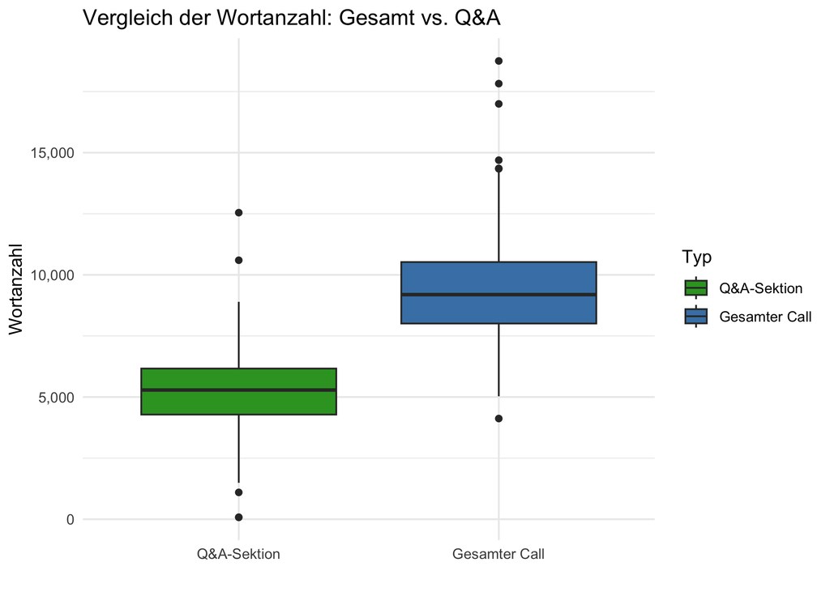

**Boxplot:** Der Boxplot zeigt die Verteilung der Wortanzahl für die Q&A-Sektions auf der linken (grün) und für den gesamten Call auf der rechten Seite (blau). Es ist gut zu erkennen, dass die Wortanzahl in den Earnings Conference Calls leicht variiert, jedoch aber typischerweise in einem höheren Bereich liegt als die Wortanzahl der Q&A-Sektion. Die durchschnittliche Wortanzahl eines Earnings Conference Calls liegt bei ca. 9000 Worten, während die Q&A-Sektion davon im Durchschnitt ca. 5500 Worte einnimmt. Der Bereich der Q&A-Sektions erstreckt sich von ca. 4000 bis 6000 Worten, wobei der gesamte Earnings Conference Call ca. 8000 bis 10500 Worte umfasst. Damit nimmt die Q&A- Sektion etwa die Hälfte des gesamten Earnings Conference Calls ein.

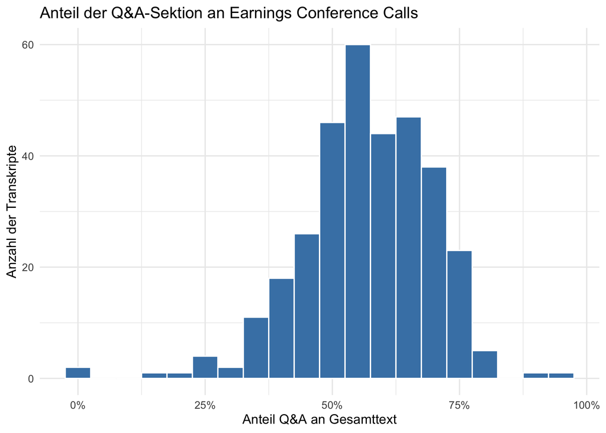

**Histogramm:** Das Histogramm zeigt die Verteilung des prozentualen Anteils der Q&A-Sektion an der gesamten Wortanzahl pro Transkriptt. Wie auch schon aus dem Boxplot zu erkennen war, nehmen die Q&A-Sektionen etwa die Hälfte des gesamten Calls ein. Es gibt sowohl nach oben als auch nach unten Ausreißer. Die meisten Q&A-Sektionen bewegen sich aber bei einem Anteil von 40% bis 75% am gesamten Earnings Conference Call. Bei genauerer Betrachtung der extrahierten Transkripte zeigt sich, dass der Außreißer mit 0% nicht richtig extrahiert wurde und damit nicht weiter zu beachten ist.

## Themenkategorien und Sentiment-Scores

Nachdem Sie nun die Earnings Conference Calls in R eingelesen und einen ersten Eindruck von deren Inhalt erhalten haben sollten Sie diese mit einem LLM (konkret mit Google Gemini) analysieren. Dafür sollten Sie einen Zero-Shot Prompt erstellen und mit Hilfe dieses Prompts die Aussage der Q&A Sektionen der Earnings Conference Calls analysieren.

9. Entwickeln Sie einen Zero-Shot Prompt für ein Large Language Model (LLM), der Earnings Conference Call Transcripts analysiert und strukturierte Sentiment-Bewertungen ausgibt. Bitte beachten Sie dabei folgende Punkte:

Zielkategorien:

- Unternehmensperformance (Finanzlage, Wachstumschancen, Unternehmensrisiken)
- Marktumfeld (Branche, Wettbewerb, externe Faktoren)

Output-Format:

- JSON-Struktur mit Sentiment-Scores von -1 (sehr negativ) bis +1 (sehr positiv)
- Keine zusätzlichen Erklärungen oder Markdown-Formatierung

Sie sollten in ihrem Prompt nach einem JSON Output verlangen (strukturiertes Format), welchen Sie mit dem Paket `jsonlite` gut in R verarbeiten können.

*Hinweis 1:* Im Anhang ist eine Erklärung für die Unterschiede zwischen einem Zero-Shot Prompt, einem One-Shot Prompt und einem Few-Shot Prompt

*Hinweis 2:* Wir haben Ihnen ein [Tutorial zusammengestellt](https://projektkurs-data-science-ulm2425.netlify.app/tutorials/zero-prompting), welches das Prompting an einem Beispiel zeigt.

**Zero-Shot Prompt (Deutsch)**

Analysiere den folgenden Text, der die Q&A-Sektion eines Earnings Conference Calls enthält.

Deine Aufgabe ist es, die Stimmung in den folgenden beiden Kategorien zu bewerten:

1. Unternehmensperformance (Finanzlage, Wachstumschancen, Unternehmensrisiken)
2. Marktumfeld (Branche, Wettbewerb, externe Faktoren)

Weise für jede Kategorie einen einzelnen Sentiment-Score zwischen -1 (sehr negativ) und +1 (sehr positiv) zu.

**Ausgabeanforderung:**

Gib ausschließlich ein gültiges JSON-Objekt in genau folgendem Format zurück, ohne zusätzlichen Text, Kommentare, Erklärungen oder Markdown-Formatierung:

{ “Unternehmensperformance”: <Wert zwischen -1 und 1>, “Marktumfeld”: <Wert zwischen -1 und 1> }

10. Im nächsten Schritt sollten Sie sich in das Paket [`ellmer`](https://ellmer.tidyverse.org/) einarbeiten. Durch `ellmer` erhalten Sie Zugriff auf alle gängigen LLMs mittels R über einen API Zugang. Wir haben ihnen für dieses Projekt ein Google Konto pro Gruppe erstellt und den API Schlüssel für jede Gruppe in das dazugehörige Repo (Readme) gepushed.
- Lesen Sie sich in das [`ellmer`](https://ellmer.tidyverse.org/) Paket ein und wie Sie den API Schlüssel für Google Gemini in ihrer .Renviron Datei hinterlegen können
- Untersuchen Sie die unterschiedlichen Modelle, die Google zur Verfügung stellt und deren Ratelimits: https://ai.google.dev/gemini-api/docs/models?hl=de

Bitte beantworten Sie folgende Fragen:

- Was sind die Vorteile/Nachteile der einzelnen Google Modelle?
- Welches (kostenlose) Modell würden Sie für ihre aktuellen Analysen bevorzugt einsetzen? Begründen Sie!
- Welche Möglichkeiten haben Sie, nicht in die Ratelimits zu kommen?
- In `ellmer` können Sie mittels dem [`params()`](https://www.tidyverse.org/blog/2025/05/ellmer-0-2-0/#parameters) Parameter auch die Temperatur ihres Modells einstellen. Was ist mit der Temperatur gemeint und was sind die Vorteile/Nachteile einer niedrigen Temperatur?

**Vorteile und Nachteile der Google Gemini-Modelle**

**Gemini 1.5 Pro / Pro 2.0:**  
- Vorteile: Sehr hohe Qualität, großes Kontextfenster, komplexe Aufgaben gut lösbar.  
- Nachteile: Höherer Preis, Tokenlimits werden schneller erreicht.

**Gemini 1.5 Flash / 2.5 Flash:**  
- Vorteile: Schneller, günstiger oder kostenlos nutzbar. Ideal für viele kurze Analysen wie unser Sentiment-Scoring.  
- Nachteile: Etwas schwächer in komplexem Reasoning und bei sehr langen Kontexten.

**Ältere Modelle:**  
- Vorteil: Stabil und günstig.  
- Nachteil: Veraltet, schlechteres Sprach- und Kontextverständnis.

**Fazit:**  
Die Flash-Modelle sind günstiger und schneller bei einfachen Aufgaben, während die Pro-Modelle sich besser für komplexe Analysen eignen.

**Welches (kostenlose) Modell würden wir für unsere aktuellen Analysen bevorzugt einsetzen?**

Wir würden das Modell **Google Gemini 2.5-flash** verwenden.  
Dieses Modell bietet den Vorteil, dass es im kostenlosen Kontingent enthalten ist und speziell für schnelle, kurze Anfragen optimiert wurde. Für unsere Aufgabe, also die Extraktion von Sentiment-Scores aus den Q&A-Texten, reicht diese Qualität vollkommen aus. Außerdem ermöglicht es uns, viele Transkripte effizient zu verarbeiten, ohne hohe Kosten zu verursachen und ohne das Tokenlimit unnötig zu belasten.

**Welche Möglichkeiten haben wir, nicht in die Ratelimits zu kommen?**

Um Ratelimits zu umgehen und den API-Zugriff nachhaltig zu gestalten, würden wir folgende Maßnahmen ergreifen:  
Wir teilen unsere Abfragen in kleinere Batches auf und speichern die Ergebnisse zwischendurch ab, sodass nicht alles auf einmal geschickt werden muss. Außerdem könnten wir gezielt Pausen mit `Sys.sleep()` zwischen den API-Aufrufen einbauen, um den Traffic gleichmäßiger zu verteilen. Wir würden den Prompt so minimal wie möglich halten, um unnötige Tokenkosten zu vermeiden, und die Temperatur auf 0 setzen, damit der Output stabil und möglichst kurz bleibt. Zusätzlich würden wir im Team unsere Nutzung sorgfältig abstimmen, um das gemeinsame Kontingent effizient zu verwalten.

**Was ist mit der Temperatur gemeint und was sind die Vorteile/Nachteile einer niedrigen Temperatur?**

**Temperatur** steuert die Zufälligkeit und Kreativität der Antwort des Modells:

- **Hohe Temperatur (z.B. 0.7–1):**
  - Vorteil: Kreativer, abwechslungsreicher Output.
  - Nachteil: Weniger konsistent, mehr Zufall und potenziell “halluzinierte” Inhalte.
- **Niedrige Temperatur (z.B. 0–0.2):**
  - Vorteil: Sehr deterministisch und reproduzierbar.
  - Nachteil: Weniger kreativ, kann eintönig wirken.

Für unsere Analyse ist eine niedrige Temperatur (z.B. 0) ideal, weil wir konsistente, vergleichbare Sentiment-Scores wollen.  
So wird das Ergebnis stabil und maschinenlesbar, was sich perfekt für eine quantitative Event-Study in R eignet.

**Fazit:**  
Für unsere Analyse würden wir **Google Gemini 2.5-flash** mit **temperature = 0** einsetzen.  
Damit erhalten wir eine schnelle, günstige und konsistente Sentiment-Analyse der Earnings Conference Call Q&A-Sektionen, die sich nahtlos in unsere R-Pipeline integrieren lässt.

11. Nutzen Sie ihren in Aufgabe 9 erstellten Prompt mit dem `ellmer` Paket und ihrem Google API-Key um alle 431 Earnings Conference Call Transkripte zu analysieren. Nutzen Sie für ihre Analyse das Modell Google Gemini 2.0-flash oder Google Gemini 2.5-flash.

Speichern Sie die Ergebnisse ihrer Analyse in einem strukturierten Tibble ab. Anschließend sollten Sie den Datensatz auch unter `data/sentiment.Rds` abspeichern.

Stellen Sie ihre Ergebnisse in einer Tabelle dar und beschreiben diese kurz:

- Wie ist der Mittelwert, Standardabweichung und Median der Einschätzung bezüglich Unternehmensperformance und Marktumfeld in ihren Earnings Conference Calls?

*Hinweis 1:* Achten Sie darauf nicht bei jedem Knitten die Analyse neu zu starten, sondern setzen Sie den Chunk dieser Aufgabe auf `eval = FALSE` und lassen Sie die Analyse nur einmal durchlaufen und speichern Sie die Ergebnisse ab (und laden diese später um damit weiterarbeiten zu können)

*Hinweis 2:* Achten Sie auf ihre Ratelimits und beanspruchen Sie den API Zugriff nicht zu stark, z.B. durch den Einbau von “sleep”-Zeiten in ihrem Code

**Übersichtstabelle: Sentiment-Scores für Unternehmensperformance und Marktumfeld**

| Kennzahl | Unternehmensperformance | Marktumfeld |
| --- | --- | --- |
| Mittelwert | 0.824 | 0.555 |
| SD | 0.139 | 0.357 |
| Median | 0.850 | 0.700 |

Die Auswertung der Sentiment-Scores aus den Earnings Conference Calls zeigt deutliche Unterschiede in der Wahrnehmung der Unternehmensperformance im Vergleich zum Marktumfeld:

**Unternehmensperformance:** Die Unternehmensperformance wird im Mittel mit einem sehr positiven Sentiment bewertet (Mittelwert=0.824, Median=0.850). Dies weist auf eine überwiegend optimistische Einschätzung seitens der Unternehmen hin. Die geringe Standardabweichung von 0.139 deutet zudem auf eine relativ einheitliche Wahrnehmung über verschiedene Unternehmen hinweg hin.

**Marktumfeld:** Das Marktumfeld wird dagegen deutlich verhaltener eingeschätzt (Mittelwert=0.555, Median=0.700), was auf eine insgesamt neutralere bis leicht positive Bewertung schließen lässt. Die höhere Standardabweichung von 0.357 zeigt eine stärkere Streuung, also unterschiedliche Einschätzungen zwischen den Unternehmen, vermutlich je nach Branche oder konjunkturellem Kontext.

Sie haben in der vorherigen Aufgabe die Stimmung bezüglich der Kategorien Unternehmensperformance und Marktperformance in den Earnings Conference Calls bestimmt. Eine Frage wäre, ob sich diese Stimmung über die Zeit hinweg verändert hat. In der folgenden Aufgabe sollen Sie sich die durchschnittliche Stimmung in diesen zwei Kategorien für die einzelnen Jahre in ihrem Datensatz näher anschauen.

12. Erstellen Sie eine geeignete Grafik um die Stimmung *aller Earnings Conference Calls eines Jahres* zu visualisieren. Tragen Sie separat die Stimmung bezüglich Unternehmensperformance und Marktumfeld ab.

Beschreiben Sie ihre Grafik.

Interpretieren Sie diese Grafik, insbesondere im Hinblick auf die gesamtwirtschaftlichen Ereignisse der letzten fünf Jahre. Hätten Sie die Ergebnisse in dieser Art erwartet?

*Hinweis:* Sie sollten sich hier eine sinnvolle Grafik überlegen, welche die Stimmungslage über die Zeit gut darstellt.

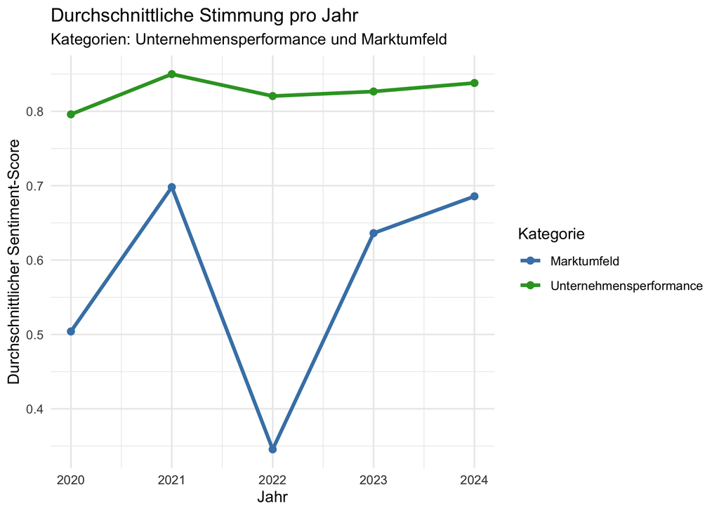

**Beschreibung der Grafik:**

Die Grafik zeigt die durchschnittlichen Sentiment-Scores pro Jahr in den Earnings Conference Calls für die beiden Kategorien Unternehmensperformane (grüne Linie) und Marktumfeld (blaue Linie). Für jedes Jahr von 2020 bis 2024 wird der jährliche Mittelwert des Sentiments dargestellt, getrennt nach Kategorie. Die Datenpunkte sind durch Linien verbunden, um zeitliche Trends zu verdeutlichen.

**Interpretation der Grafik:**

**Marktumfeld:** Die Einschätzungen zum Marktumfeld sind deutlich schwankender und insgesamt zurückhaltender. 2022 fällt besonders auf, hier gibt es einen massiven Einbruch der Stimmung (Score unter 0.4). Der Auslöser für diesen Einruch könnte der Ukraine-Krieg sein. Danach folgt ein Aufwärtstrend und 2024 liegt der Wert wieder nahe 0.7. Dies spiegelt die Wahrnehmung eines volatilen externen Umfelds, das sich zuletzt stabilisiert hat.

**Erwartung vs. Realität:**

Die positive Einschätzung der Unternehmensperformance überrascht nicht, da viele Unternehmen gelernt haben, sich auch in schwierigen Zeiten anzupassen (Digitalisierung, Effizienzsteigerung). Die starke Volatilität beim Marktumfeld war zu erwarten, denn äußere Einflüsse wie Pandemie, Krieg und Inflation haben das Vertrauen in de Rahmenbedingungen stark beeinflusst. Besonders auffällig ist dabei der Stimmungseinbruch 2022, der gut zur geopolitischen und ökonomischen Realität passt.

# Eventstudie

Um zu evaluieren, ob die Earnings Conference Calls tatsächlich einen Einfluss auf die Aktienkurse der einzelnen Unternehmen hatten können Sie eine sogenannte Eventstudie durchführen, welche Sie bereits in Aufgabe 1 kennen gelernt haben. Bei einer Eventstudie betrachten Sie nur die Zeit (bei uns die Tage) unmittelbar vor oder nach einem Event. In diesem Projekt ist ein Event ein Earnings Conference Call des jeweiligen Unternehmens. Sie sollen in diesem Projekt herausfinden, wie sich über alle Unternehmen hinweg die Earnings Conference Calls auf die Aktienrenditen auswirken.

13. Verbinden Sie den Datensatz über die *Stimmung der Earnings Conference Calls (sentiment.Rds)* zu den einzelnen Unternehmen mit den *abnormalen Renditen* und speichern diesen Datensatz als `gesamtdatensatz` in R ab. Sie können das RIC-Kürzel und Datum für den Join verwenden. Sollte der Earnings Conference Call an keinem Handelstag stattgefunden haben, so joinen Sie bitte mit dem darauffolgenden Handelstag.
- Für die Tage an denen ein Earnings Conference Call stattgefunden hat sollten Sie eine Variable `event` generieren, welche an dem Tag des Calls gleich 0 ist.
- Für die Tage vor dem Earnings Conference Call (Event) sollte die Variable `event` rückwärts zählen (bis zu -5). Für alle Tage nach dem Event sollte die Variable `event` fortgeführt werden (bis +5).
- Erstellen Sie eine Variable `ar_505`, welche die *abnormalen Rendite* von Tag -5 bis +5 **fortlaufend** aufsummiert
- Erstellen Sie eine Variable `car_101`, welche die kumulierte abnormale Rendite im Zeitraum -1 bis +1 um das Event beinhaltet
- Erstellen Sie weiterhin diese sechs neuen Variablen:
  - `negativ_firm` = Wenn die Unternehmensperformance als negativ eingeschätzt wird
  - `neutral_firm` = Wenn die Unternehmensperformance als neutral eingeschätzt wird
  - `positiv_firm` = Wenn die Unternehmensperformance als positiv eingeschätzt wird
  - `negativ_market` = Wenn die Marktperformance als negativ eingeschätzt wird
  - `neutral_market` = Wenn die Marktperformance als neutral eingeschätzt wird
  - `positiv_market` = Wenn die Marktperformance als positiv eingeschätzt wird
- Erstellen Sie Dummy Variablen, die 1 sind für ein bestimmtes Jahr. Bspw. eine Dummyvariable die 2020 heißt und für alle Beobachtungen im Jahr 2020 sollte diese Variable 1 sein, 0 sonst. Tun Sie dies für alle Jahre in ihrem Datensatz

*Hinweis:* Die Funktion cumsum() könnte für diese Aufgabe hilfreich sein

14. Erstellen Sie je ein Liniendiagramm für die von ihnen betrachteten Unternehmen: Eines für die Stimmung bezüglich der Unternehmensperformance und eines bezüglich der Marktperformance.

Sie sollten in ihren Grafiken die kumulierten Renditen im Zeitraum [-5,5] Tage um einen Earnings Conference Call darstellen. - Die Variable “Event” sollte die Tage vor und nach dem Earnings Conference Call enthalten ([-5,5]) und auf der x-Achse dargestellt werden - Die Variable `ar_505` sollte die durchschnittliche kumulierte abnormale Rendite für den jeweiligen Tag auf der y-Achse abtragen (für alle Unternehmen in ihrem Datensatz) - In jeder Grafik sollten Sie eine extra Linie zeichnen für Earnings Conference Calls mit einer positiven/negativen und neutralen Stimmung und deren Einfluss auf den Aktienmarkt

Beschreiben und interpretieren Sie ihre Grafik. Gehen Sie hierbei insbesondere darauf ein, welche Erwartungen Sie auf der Basis ihrer Lektüre aus Aufgabe 1 hatten und in wie weit diese Erwartungen sich erfüllt haben.

*Hinweis:* In diesen Grafiken stellen Sie nicht jedes Event (d.h. die Auswirkungen eines jeden Earnings Conference Calls) einzeln dar, sondern gesamt für alle Earnings Conference Calls.

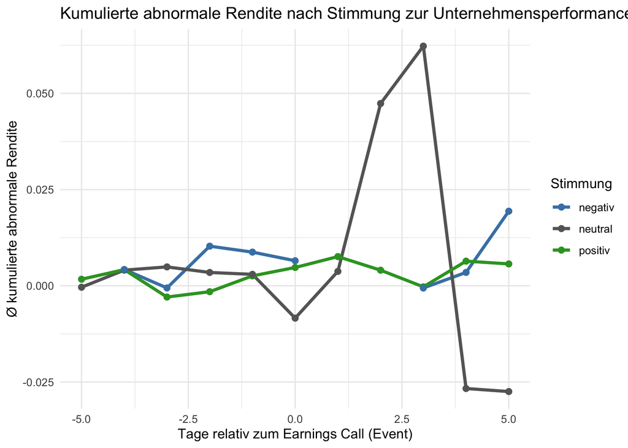

**Beschreibung der Grafik:**

Die Grafik zeigt den Verlauf der durchschnittlichen kumulierten abnormalen Renditen in Abhängigkeit von der Stimmung zur Unternehmensperformance im Zeitraum von fünf Tagen vor bis fünf Tage nach dem Earnings Conference Call. Auf der x-Achse sind die Tage relativ zum Event dargestellt (wobei Tag 0 den Call selbst markiert), auf der y-Achse die durchschnittliche kumulierte abnormale Rendite. In der Grafik sind drei Linien zu erkennen, die jeweils für eine negative (blau), neutrale (grau) oder positive (grün) Einschätzung der Unternehmensperformance stehen.

**Interpretation der Grafik:**

Dieses Ergebnis widerspricht der klassischen Erwartung, wonach positive Einschätzungen zu positiven Renditen führen sollten. Eine mögliche Erklärung könnte sein, dass die “positive” Stimmung bereits vom Markt antizipiert wurde und somit keine Überraschung darstellte. Neutral bewertete Unternehmen hingegen könnten die Erwartungen der Marktteilnehmer übertroffen haben, was zu einer positiven Kursreaktion führte. Auch denkbar ist, dass sich die Stimmungsbewertung auf die Wortwahl der Kommunikation stützt, während der Markt eher auf implizite Informationen und den Tonfall achtet.

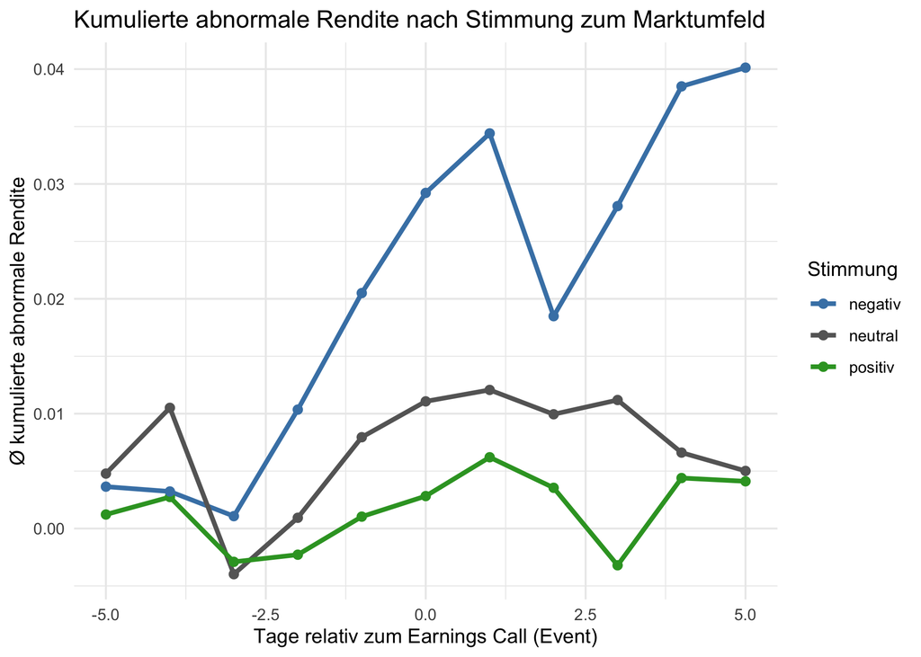

**Beschreibung der Grafik:**

Die zweite Grafik stellt ebenfalls den Verlauf der durchschnittlichen kumulierten abnormalen Renditen dar, dieses Mal jedoch im Hinblick auf die Stimmung zum allgemeinen Marktumfeld, wie es während der Earnings Calls thematisiert wurde. Auch hier sind die Tage relativ zum Event auf der x-Achse und die kumulierten abnormalen Renditen auf der y-Achse abgetragen. Wiederum sind drei Linien zu erkennen, die die Stimmung als negativ (blau), neutral (grau) oder positiv (grün) klassifizieren.

**Interpretation der Grafik:**

Diese Beobachtung steht im Widerspruch zur Erwartung, dass ein positives Marktumfeld die Kurse begünstigen sollte. Eine mögliche Erklärung könnte sein, dass negative Aussagen zum Marktumfeld bereits in den Erwartungen eingepreist waren und somit keine negative Überraschung darstellten. Stattdessen könnte die Fähigkeit eines Unternehmens, sich in einem schwierigen Marktumfeld zu behaupten, vom Markt positiv bewertet worden sein. Ebenso wäre es denkbar, dass negative Marktaussichten von den Investoren als Hinweis auf bevorstehende politische oder wirtschaftliche Stimuli interpretiert wurden, was wiederum als Chance gesehen wird.

**Zusammenfassend** lässt sich sagen, dass die Marktreaktionen sowohl auf die Stimmung zur Unternehmensperformance als auch zum Marktumfeld nicht linear und nicht immer intuitiv nachvollziehbar sind. Dies unterstreicht die Bedeutung einer differenzierten Betrachtung von Stimmungsanalysen: Nicht nur die inhaltliche Bewertung, sondern auch Kontext, Erwartungshaltungen und möglicherweise subtile Signale im Kommunikationsstil der Unternehmen scheinen eine wesentliche Rolle bei der Reaktion der Aktienmärkte zu spielen.

# Regressionen

Sie haben bisher den Einfluss der Earnings Conference Calls auf die Aktienrendite der größten europäischen Unternehmen im Technologie-Sektor visuell betrachtet. Im letzten Abschnitt dieser Projektarbeit analysieren Sie ihre Daten mittels linearer Regressionen.

15. In dieser Aufgabe sollten Sie zwei Regressionen erstellen:

Regressieren Sie die kumulierten abnormalen Renditen um das Event `car_101` auf die Dummyvariablen

- `negativ_firm` und `negativ_market` in der ersten Regression und
- `positiv_firm` und `positiv_market` in der zweiten Regression.

Diese Dummyvariablen geben die Stimmung in den Earnings-Conference Calls wieder.

Beschreibung und interpretieren Sie ihre Regressionsergebnisse und gehen Sie dabei auch auf folgende Fragen ein:

- Was ist die Vergleichsgruppe in den beiden Regressionen?
- Was sind die Voraussetzungen für eine kausale Interpretation der Koeffizienten. Sind diese ihrer Meinung nach gegeben?

|  | Negativ-Stimmung | Positiv-Stimmung |
| --- | --- | --- |
| Negativ: Unternehmen | −0.018** |  |
|  | (0.006) |  |
| Negativ: Markt | 0.008*** |  |
|  | (0.002) |  |
| Positiv: Unternehmen |  | 0.005 |
|  |  | (0.003) |
| Positiv: Markt |  | 0.004*** |
|  |  | (0.001) |
| Num.Obs. | 59790 | 59790 |
| R2 | 0.000 | 0.000 |
| R2 Adj. | 0.000 | 0.000 |
| AIC | −124136.7 | −124139.5 |
| BIC | −124100.7 | −124103.5 |
| Log.Lik. | 62072.355 | 62073.731 |
| F | 11.059 | 12.436 |
| RMSE | 0.09 | 0.09 |

+ p < 0.1, * p < 0.05, ** p < 0.01, *** p < 0.001

**Ergebnisse der Regression:**

Die erste Regression zeigt, dass eine negative Stimmung zur Unternehmensperformance im Durchschnitt mit einem signifikanten Rückgang der kumulierten abnormalen Rendite um 1,8 Prozentpunkte verbunden ist. Dies ist ein deutlicher Effekt und legt nahe, dass der Kapitalmarkt pessimistische Aussagen zur eigenen Geschäftsentwicklung als klares Negativsignal interpretiert. Interessanterweise zeigt sich bei negativer Einschätzung des Marktumfelds ein positiver Effekt von 0,8 Prozentpunkten auf die Rendite. Dieser Befund ist auf den ersten Blick kontraintuitiv. Mögliche Erklärungen dafür sind, dass Unternehmen im Vergleich zum negativ bewerteten Umfeld als widerstandsfähig wahrgenommen werden oder dass bereits antizipierte schlechte Marktbedingungen offen angesprochen und somit als glaubwürdiges Zeichen der Transparenz interpretiert werden.

In der zweiten Regression zeigt sich, dass positive Aussagen zur Unternehmensperformance mit einem leichten positiven Effekt von 0,5 Prozentpunkten verbunden sind, während positive Aussagen zum Marktumfeld die Rendite um 0,4 Prozentpunkte erhöhen. Beide Effekte sind im Vergleich zur negativen Unternehmensbewertung deutlich schwächer ausgeprägt, was auf eine gewisse Asymmetrie in der Marktreaktion hinweist: Negative Informationen haben in der Regel eine stärkere Wirkung als positive.

**Was ist die Vergleichsgruppe in den beiden Regressionen?**

In beiden Regressionen stellt die Vergleichsgruppe jene Earnings Conference Calls dar, bei denen die Stimmung als neutral eingestuft wurde – also weder deutlich positiv noch negativ war. Entsprechend sind die geschätzten Koeffizienten als Abweichungen von dieser neutralen Baseline zu interpretieren.

**Was sind die Voraussetzungen für eine kausale Interpretation der Koeffizienten. Sind diese ihrer Meinung nach gegeben?**

Für eine kausale Interpretation der Regressionskoeffizienten müssten mehrere Bedingungen erfüllt sein:

**Keine unbeobachtete Confounder:** Es dürfte keine Drittvariablen geben, die sowohl die Stimmung im Call als auch die Renditen beeinflussen. Beispielsweise könnten bereits im Vorfeld veröffentlichte Informationen (z. B. durch Vorabmeldungen oder Leaks) sowohl die Stimmung als auch die Kursentwicklung beeinflussen.

**Exogenität der erklärenden Variablen:** Die Stimmung im Call müsste unabhängig von erwarteten Kursbewegungen sein. In der Realität ist dies schwer zu garantieren, da Manager möglicherweise Aussagen gezielt anpassen, um bestimmte Marktreaktionen zu beeinflussen.

**Keine Selektion:** Nur wenn alle Earnings Conference Calls systematisch und nicht selektiv (z. B. nur bei erwarteter guter Nachricht) abgehalten werden, kann Verzerrung durch Auswahlverhalten ausgeschlossen werden.

**Richtige Spezifikation:** Die verwendeten Dummyvariablen müssen die Stimmung ausreichend gut und objektiv abbilden. Falls dies durch Verzerrungen bei der Sentimentanalyse oder durch inhaltlich uneinheitliche Aussagen nicht der Fall ist, leidet die Validität der Interpretation.

**Fazit:**

Aufgrund der genannten Punkte sind die Voraussetzungen für eine kausale Interpretation nicht vollständig gegeben. Zwar lässt sich ein statistisch signifikanter Zusammenhang zwischen Stimmung und Rendite feststellen, doch können andere, unbeobachtete Faktoren nicht ausgeschlossen werden. Daher sollten die Ergebnisse als korrelative Zusammenhänge interpretiert werden, nicht als Beweis für eine kausale Wirkung.

16. In ihrer deskriptiven Analyse haben Sie bereits gesehen, dass die Unternehmen, die Sie in diesem Projekt betrachten, alle unterschiedlich groß sind. Weiterhin haben Sie gesehen, dass es ein unterschiedliches Stimmungsbild in den Calls über die einzelnen Jahre hinweg gibt. Dafür möchten Sie in ihren Regressionen nun kontrollieren.
    1. Regressieren Sie die `car_101` auf die Variablen *negativ_firm* und *negativ_market* und kontrollieren Sie auf die Größe des jeweiligen Unternehmens, indem Sie die Variable *Total_Assets* in ihre Regression aufnehmen
    2. Fügen Sie in einer zweiten Analyse zusätzlich zu den Variablen aus der 1. Regression auch noch Dummyvariablen für die Jahre in dem das Event stattgefunden hat ihrer Regression hinzu.
    3. Führen Sie die Regressionen aus 1. und 2. auch für die Variablen *positiv_firm* und *positiv_market* anstatt *negativ_firm* und *negativ_market* durch, sodass Sie am Ende 4 Regressionen haben

Beschreiben und interpretieren Sie ihre Ergebnisse im Hinblick auf die Größe der Koeffizienten und deren Signifikanz. Gehen Sie insbesondere auf folgende Fragen ein:

- Warum sollte ihre Regression nicht fünf Dummyvariablen, je eine für jedes Jahr, sondern nur vier beinhalten?
- Verändert sich durch die Dummyvariablen der Koeffizient von *negativ_firm* und *negativ_market* bzw. *positiv_firm* und *positiv_market*?
- Hätten Sie eine Veränderung des Koeffizienten von *negativ_firm*, *negativ_market*, *positiv_firm* oder *positiv_market* erwartet? Begründen Sie ihre Antwort mit ihren deskriptiven Analysen.

|  | Negativ ohne Dummies | Negativ mit Dummies | Positiv ohne Dummies | Positiv mit Dummies |
| --- | --- | --- | --- | --- |
| Negativ: Unternehmen | −0.026*** | −0.026*** |  |  |
|  | (0.006) | (0.006) |  |  |
| Negativ: Markt | 0.003 | 0.003 |  |  |
|  | (0.002) | (0.002) |  |  |
| Positiv: Unternehmen |  |  | 0.014*** | 0.014*** |
|  |  |  | (0.003) | (0.003) |
| Positiv: Markt |  |  | 0.006*** | 0.006*** |
|  |  |  | (0.001) | (0.001) |
| Num.Obs. | 59790 | 59790 | 59790 | 59790 |
| R2 | 0.111 | 0.111 | 0.112 | 0.112 |
| R2 Adj. | 0.106 | 0.107 | 0.107 | 0.107 |
| AIC | −130558.7 | −130573.0 | −130607.4 | −130621.1 |
| BIC | −127913.2 | −127891.4 | −127961.8 | −127939.6 |
| Log.Lik. | 65573.373 | 65584.490 | 65597.704 | 65608.573 |
| F | 25.400 |  | 25.587 |  |
| RMSE | 0.08 | 0.08 | 0.08 | 0.08 |

+ p < 0.1, * p < 0.05, ** p < 0.01, *** p < 0.001

**Interpretation:**

Für die Stimmung zum Gesamtmarkt zeigt sich hingegen ein differenziertes Bild: Während eine positive Markteinschätzung ebenfalls einen signifikanten, aber kleineren positiven Effekt auf die CAR hat (ca. +0,6 Prozentpunkte), ist der Effekt einer negativen Markteinschätzung statistisch nicht signifikant.

Die Einbeziehung von Jahresdummies verändert die geschätzten Koeffizienten der Stimmungsvariablen nicht, was darauf hindeutet, dass die Wirkung der Stimmungsindikatoren über die Jahre hinweg robust und stabil ist. Dies spricht für eine konstante Reaktion der Kapitalmärkte auf Stimmungsinformationen aus Earnings Calls, unabhängig vom jeweiligen Marktumfeld oder makroökonomischen Kontext.

Insgesamt unterstreichen die Ergebnisse die Relevanz qualitativer Stimmungsindikatoren aus Earnings Calls für Investoren: Besonders die unternehmensspezifische Tonalität scheint ein wichtiger Treiber kurzfristiger Marktreaktionen zu sein.

**Warum sollte ihre Regression nicht fünf Dummyvariablen, je eine für jedes Jahr, sondern nur vier beinhalten?**

Das liegt am sogenannten Dummy-Variable-Trap, also an der Multikollinearität, die auftritt, wenn man für eine kategoriale Variable wie das Jahr alle möglichen Kategorien (also z.B. 2020 bis 2024) als Dummyvariablen in das Modell aufnimmt und zusätzlich einen Intercept (Achsenabschnitt) modelliert. Um diese perfekte Multikollinearität zu vermeiden, lässt man einen Jahrgang (z.B. 2020) weg. Dieser dient dann als Referenzkategorie. Die geschätzten Effekte der restlichen Jahre (2021–2024) geben dann an, wie stark sich die abhängige Variable im Vergleich zum Basisjahr (2020) verändert.

**Verändert sich durch die Dummyvariablen der Koeffizient von *negativ_firm* und *negativ_market* bzw. *positiv_firm* und *positiv_market*?**

Das Hinzufügen der Jahresdummies verändert die geschätzten Effekte der Hauptvariablen nicht. Das bedeutet, dass sich der Effekt z.B. von negativer Unternehmensstimmung nicht wesentlich unterscheidet zwischen den Jahren – oder dass dieser Effekt bereits stabil genug ist und nicht mit den Zeitfaktoren interagiert.

**Hätten Sie eine Veränderung des Koeffizienten von *negativ_firm*, *negativ_market*, *positiv_firm* oder *positiv_market* erwartet? Begründen Sie ihre Antwort mit ihren deskriptiven Analysen**

Ja, eine Veränderung der Regressionskoeffizienten bei Aufnahme von Jahresdummies war grundsätzlich zu erwarten, da die deskriptive Analyse bereits gezeigt hat, dass sich die Verteilung der Stimmungsurteile über die Jahre hinweg deutlich verändert hat. In einigen Jahren waren z. B. deutlich mehr Unternehmen mit negativer Tonalität vertreten, während in anderen Jahren ein positiveres Bild überwog. Solche Veränderungen in der Häufigkeit und Intensität von Stimmungen können dazu führen, dass der durchschnittliche Effekt einer bestimmten Stimmung über alle Jahre hinweg verzerrt wird, wenn man nicht für das jeweilige Jahr kontrolliert.

Mit der Aufnahme von Jahresdummies in die Regressionen wird nun ein Teil der zeitlichen Schwankung herausgerechnet, was theoretisch zu einer Veränderung der geschätzten Koeffizienten führen könnte – insbesondere, wenn z. B. negative Unternehmensstimmung in einem Jahr besonders starke oder besonders schwache Marktreaktionen ausgelöst hat.

In der konkreten Analyse jedoch blieben die Koeffizienten der Stimmungsvariablen auch nach Kontrolle für Jahresdummies nahezu unverändert. Das deutet darauf hin, dass die Richtung und Stärke des Zusammenhangs zwischen Stimmung und Marktreaktion trotz zeitlicher Schwankungen im Stimmungsbild stabil ist. Die Kapitalmärkte reagieren also offenbar konsistent auf Stimmungsinformationen – unabhängig vom Jahr.

17. Zum Abschluss sollten Sie dazu Stellung beziehen, in wie weit die Erkenntnisse aus diesem Projekt für eine Handelsstrategie genutzt werden könnten. Konkret sollten Sie erläutern ob es sinnvoll ist eine Unternehmensaktie bei einem negativem Sentiment im Earnings Conference Call automatisiert zu verkaufen.

Beziehen Sie sich in ihrer Argumentation insbesondere auf:

- Zeitliche Aspekte (Wann reagiert der Markt vs. wann liegt das Sentiment vor?)
- Methodische Limitationen Ihrer Event Study
- Unsicherheiten bei der LLM-Sentiment-Analyse

Begründen Sie jeden Kritikpunkt konkret mit Bezug auf Ihre Projektarbeit und schließen Sie mit einer realistischen Einschätzung ab: Wofür könnten Ihre Ergebnisse trotz dieser Limitationen in der Praxis dennoch wertvoll sein?

Die Ergebnisse unserer Event-Study zeigen, dass das Sentiment aus Earnings Conference Calls tatsächlich mit kurzfristigen, signifikanten Kursreaktionen zusammenhängt. Insbesondere haben wir gesehen, dass eine negative Einschätzung der Unternehmensperformance im Call in unseren Regressionsanalysen mit einem klaren Rückgang der kumulierten abnormalen Rendite (CAR_101) um ca. 2,6 Prozentpunkte verbunden ist. Dies deutet zunächst darauf hin, dass es prinzipiell attraktiv sein könnte, solche Calls als Verkaufssignal für eine Handelsstrategie zu nutzen.

**Allerdings sprechen mehrere praktische und methodische Gründe dagegen, eine Unternehmensaktie automatisiert allein aufgrund eines negativen Sentiments im Call sofort zu verkaufen.**

**Zeitliche Aspekte**

Ein zentrales Problem ist das Timing:

- Unsere Event-Study definiert Tag 0 als den Tag des Earnings Calls und misst die abnormale Rendite typischerweise im Fenster von -1 bis +1 Tagen.
- Unsere Analyse hat gezeigt, dass die größten Effekte häufig unmittelbar oder sehr kurzfristig nach dem Event eintreten (z.B. im CAR_101-Fenster oder sogar in Intraday-Bewegungen).
- In der Realität liegt das Transkript eines Calls jedoch oft erst nach dem Handelstag vor (teilweise Stunden oder einen Tag verzögert). Selbst wenn der Call live verfolgt wird, müsste das Sentiment in Echtzeit extrahiert werden.
- Unsere LLM-basierte Sentimentanalyse war aber nicht live, sondern ex-post durchgeführt. In unserer Pipeline haben wir zunächst Texte gesammelt, anschließend die Q&A-Abschnitte extrahiert und dann mit dem LLM bewertet – was mehrere Schritte und Zeit erfordert.

**Fazit:** Eine Handelsstrategie, die auf ex-post ausgewertetem Sentiment basiert, würde vermutlich zu spät reagieren und könnte große Teile der eigentlichen Marktbewegung verpassen.

**Methodische Limitationen der Event-Study**

Unsere Event-Study-Methode hat zentrale Annahmen:

**Keine konkurrierenden Ereignisse:** Wir haben angenommen, dass keine anderen Nachrichten die Aktie gleichzeitig bewegen. In der Praxis gibt es jedoch oft parallele Pressemitteilungen, Makrodaten oder Analystenreaktionen.

**Stabile Erwartungen:** Wir haben die abnormale Rendite gegen eine Marktrendite bereinigt, aber nicht gegen detaillierte Erwartungen oder firmenspezifische Beta-Risiken.

**Kontrafaktische Validität:** Unsere Benchmark-Renditen (Total Return Index) bilden nur einen Durchschnitt ab und ignorieren firmenspezifische Unterschiede.

**Außerdem haben wir gesehen:**

- Die Effekte variieren über die Jahre, auch wenn die Regressionskoeffizienten relativ stabil blieben. Unsere Analyse zeigte z.B. starke Schwankungen im Marktumfeldsentiment im Jahr 2022, vermutlich ausgelöst durch den Ukrainekrieg.
- Diese makroökonomischen Faktoren können die Wirkung der Earnings Calls auf die Renditen überlagern.

**Fazit:** Die gemessene Korrelation zwischen Sentiment und Rendite ist keine saubere Kausalität. Eine Handelsstrategie müsste konkurrierende Effekte und Marktbedingungen mitberücksichtigen.

**Unsicherheiten der LLM-Sentiment-Analyse**

Unsere Sentimentmessung basierte auf einer LLM-basierten Klassifikation. Dabei sind mehrere Unsicherheiten zu bedenken:

**Prompt-Sensitivität:** Unsere Zero-Shot-Prompts lieferten strukturierte JSON-Werte, aber kleine Änderungen im Prompt können das Ergebnis verschieben.

**Kontextreduktion:** Wir haben nur die Q&A-Sektion analysiert und bewusst andere Teile des Calls ausgeschlossen. Unsere Grafik zur Wortanzahl zeigte aber, dass die Q&A-Sektion im Schnitt nur etwa 50% des Textes ausmacht. Kritische Aussagen könnten auch im vorbereiteten Teil enthalten sein.

**Skalenunsicherheit:** Unsere Scores bewegten sich typischerweise im positiven Bereich (z.B. Unternehmensperformance-Mittelwert ~0.82). Eine solche Verzerrung bedeutet, dass „negative“ Calls oft nur relativ negativ waren.

**Interpretation durch LLM:** Das Modell bewertet die Stimmung nach Sprache, nicht nach ökonomischem Kontext. Ironie, komplexe Andeutungen oder juristische Formulierungen können falsch interpretiert werden.

**Fazit:** Das Sentiment-Label ist eine nützliche, aber unvollkommene Approximation der wahren Marktreaktionserwartung. Für automatisierte Strategien wäre eine robustere und validierte Klassifikation nötig.

**Abschließende Einschätzung: Wofür sind unsere Ergebnisse dennoch nützlich?**

Trotz aller Limitationen zeigt unsere Analyse klar:

- Es existiert ein systematischer Zusammenhang zwischen Earnings Call Sentiment und kurzfristigen abnormalen Renditen.
- Insbesondere negative Aussagen zur Unternehmensperformance lösen signifikant negative Kursbewegungen aus.
- Diese Erkenntnis kann Investoren helfen, Earnings Calls systematisch zu beobachten und zu bewerten – z.B. für diskretionäre Entscheidungen oder als ein Signal in einem Multi-Faktor-Modell.
- Asset Manager könnten solche Signale in Risikomodellen oder Frühwarnsystemen berücksichtigen.
- Research-Abteilungen können die LLM-basierte Sentimentanalyse nutzen, um analystische Ressourcen zu ergänzen und Calls effizienter auszuwerten.

Eine rein automatisierte Buy/Sell-Strategie nur auf Basis eines simplen Sentimentsignals aus einem Earnings Call erscheint dagegen nicht sinnvoll, da Timing-Probleme, methodische Annahmen und Klassifikationsunsicherheiten dies derzeit nicht zuverlässig genug erlauben.

**Kurz gesagt:**

Unsere Ergebnisse liefern wertvolle Information – aber eher als ergänzendes Input in einem professionellen Entscheidungsprozess, nicht als alleinige Entscheidungsregel.

# Zusatzaufgabe

In Aufgabe 6 berechnen Sie die *abnormalen Renditen* der einzelnen von ihnen betrachteten Unternehmen. Nun könnte es allerdings sein, dass es nicht ausreicht den Marktindex einfach von der Aktienrendite abzuziehen um für die erwartete Performance der Aktie zu kontrollieren. Potentiell wäre es besser für die durchschnittliche Performance der Aktie zu kontrollieren in der keine Events stattfinden.

Sie können eine solche durchschnittliche Performance schätzen. Dazu sollten Sie eine Schätzperiode *vor* dem Event definieren. Diese Periode sollen Sie auf 120 bis 10 Handelstage vor dem Event festlegen. Die durchschnittliche Rendite der Einzelaktie sollten Sie in dieser Periode auf die Marktrendite regressieren. Dieses Modell wird `Risk-adjusted returns model` in Huntington-Klein (2021) genannt:

$$\begin{equation}
\hat{Rendite}_{i,t} = \alpha + \beta Rendite_{m,t}
\end{equation}$$

Anschließend nutzen Sie die vorhergesagten Werte und ziehen diese in der Eventphase von der Rendite der Einzelaktie ab.

18. Erstellen Sie die kumulierten abnormalen Renditen im Zeitraum -5 bis +5 mit Hilfe ihres Risk-adjusted returns model neu (und nennen diese `mar_505`). Erstellen Sie die kumulierten abnormalen Renditen im Zeitraum -1 bis +1 um das Event mit Hilfe ihres Risk-adjusted returns model neu (und nennen die Variable `cmar_101`) und vergleichen die Werte in einer geeigneten Grafik mit den Ergebnissen aus dem market-adjusted returns model (`car_101`).
- Gibt es hier große Unterschiede?
- Warum gibt es diese Unterschiede, oder warum sehen Sie nur geringe Unterschiede?

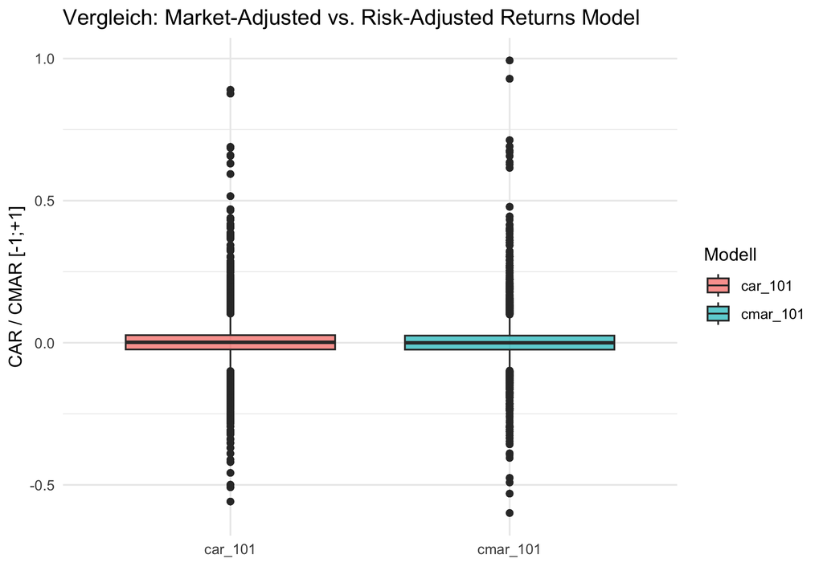

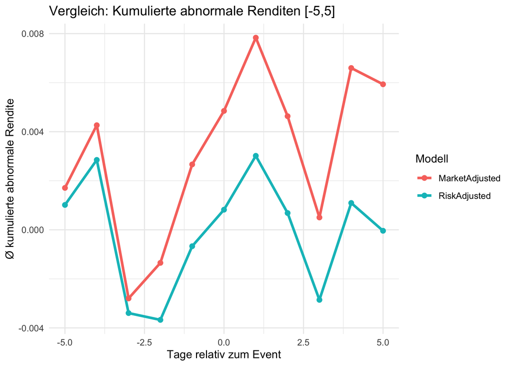

Wir haben die kumulierten abnormalen Renditen mit dem Risk-Adjusted Returns Model neu berechnet. Dazu haben wir in einer Schätzperiode von 120 bis 10 Handelstagen vor dem Event die Renditen jeder Aktie auf die Marktrendite regressiert. Die so geschätzten erwarteten Werte wurden im Eventfenster von den tatsächlichen Renditen abgezogen.

Wir haben dann folgende Größen berechnet:

**mar_505:** kumulierte abnormalen Renditen von Tag -5 bis +5 (Risk-Adjusted)

**cmar_101:** kumulierte abnormalen Renditen von Tag -1 bis +1 (Risk-Adjusted)

Diese wurden mit dem bisherigen Market-Adjusted-Modell (car_101) verglichen.

**Gibt es hier große Unterschiede?**

Wir sehen nur relativ kleine Unterschiede im zentralen Bereich, aber größere Abweichungen in den Extremen:

**Boxplot-Vergleich [-1;+1]:**

Beide Modelle haben ähnliche Medianwerte und zentrale Streuung. Allerdings zeigt das Risk-Adjusted-Modell (cmar_101) eine höhere Zahl an Extremwerten und eine größere Gesamtausreißer-Streuung. → Das deutet auf mehr Volatilität und Ausreißerempfindlichkeit hin.

**Liniendiagramm [-5;+5]:**

Beide Linien zeigen insgesamt ähnliche Bewegungen um das Eventdatum, aber das Risk-Adjusted-Modell liegt etwas unter dem Market-Adjusted-Modell. → Die Risk-Adjusted-Kurve zeigt ebenfalls kleinere Abweichungen um Tag 0 und wirkt insgesamt flacher.

**Warum gibt es diese Unterschiede – oder warum sehen wir nur geringe Unterschiede?**

Die Unterschiede sind gut erklärbar:

**Geringe Unterschiede im Median:**

- Beide Modelle nutzen letztlich den Marktindex als Haupterklärer.
- Bei sehr großen, liquiden Tech-Aktien ist Beta oft nahe 1. Das erklärt, warum der zentrale Trend sehr ähnlich ist.

**Unterschiede bei Ausreißern und Streuung:**

- Das Risk-Adjusted-Modell schätzt für jedes Unternehmen ein eigenes Beta und Alpha.
- Bei kleineren oder weniger liquiden Aktien können diese Schätzungen stark schwanken.
- Diese Schätzunsicherheit kann in den Eventfenstern zu stärkeren Ausschlägen führen.
- Außerdem ist das Risk-Adjusted-Modell empfindlicher für Rauschen oder Sondereffekte in der Schätzperiode.

**Interpretation:**

- Das Market-Adjusted-Modell ist robuster, weil es einfach den Marktindex abzieht – ohne Betaanpassung.
- Das Risk-Adjusted-Modell ist theoretisch genauer, weil es firmenspezifisches Risiko berücksichtigt, aber in der Praxis fehleranfälliger bei kleinen Datenmengen.

**Fazit:**

- Beide Modelle liefern im Mittel ähnliche Aussagen über die durchschnittliche Marktreaktion um Earnings Calls.
- Das Risk-Adjusted-Modell bietet etwas mehr Präzision auf Einzelfallebene, hat aber auch mehr Ausreißer.
- Für groß angelegte Event-Studien (wie hier) ist das einfache Market-Adjusted-Modell oft stabiler und besser interpretierbar.
19. Erstellen Sie die Grafik von Aufgabe 12 neu.

Beschreiben und interpretieren Sie ihre Grafik. Gehen Sie auch auf folgende Fragen ein:

- Könnte es zu Problemen führen, wenn in der Schätzperiode vor dem Event ein weiterer Earnings-Conference Call enthalten ist?
  - Warum könnte dies ein Problem sein, oder warum nicht?

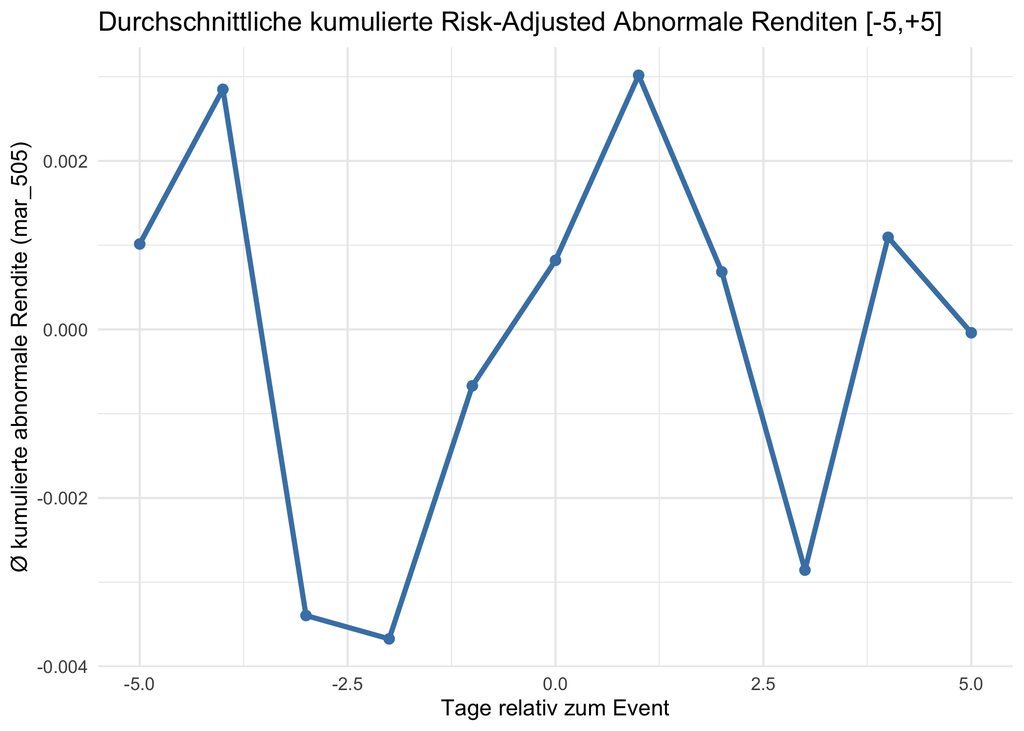

**Beschreibung und Interpretation der Grafik**

Die Grafik zeigt den durchschnittlichen Verlauf der kumulierten abnormalen Renditen (mar_505) im Risk-Adjusted Returns Model von -5 bis +5 Tagen um den Earnings Conference Call.

- Insgesamt liegen die Werte eng um die Null-Linie, ohne große systematische Ausschläge.
- Rund um den Eventtag (Tag 0) ist ein leichter Anstieg erkennbar, der aber schnell wieder abflacht.
- Dies deutet darauf hin, dass die im Risk-Adjusted Modell bereinigten Effekte insgesamt moderat und weniger ausgeprägt sind als im einfacheren Market-Adjusted Modell.
- Die schwankende Linie zeigt auch, dass mehr Rauschen enthalten sein kann, da das Modell firmenspezifische Risiken schätzt und Fehler in der Alpha- und Beta-Bestimmung wirken.

**Könnte es zu Problemen führen, wenn in der Schätzperiode vor dem Event ein weiterer Earnings-Conference Call enthalten ist?**

Ja – das wäre problematisch.

- Die Schätzperiode soll das normale Renditeverhalten ohne Event-Effekte abbilden.
- Wenn dort schon ein Earnings Call liegt, verfälschen dessen abnormale Renditen die Schätzung von Alpha und Beta.
- Diese verzerrten Parameter führen zu falschen Erwartungen im Eventfenster – und damit zu verfälschten abnormalen Renditen.
- Deshalb sollte die Schätzperiode clean sein und keine weiteren Earnings Events enthalten.

In der Praxis wird das oft berücksichtigt, indem man solche Perioden vorher ausfiltert.

20. Lesen Sie das Kapitel [“Fixed Effects” in Huntington-Klein (2021)](https://theeffectbook.net/ch-FixedEffects.html#how-does-it-work), speziell Kapitel 16.1
21. Regressieren Sie die `cmar_101` auf die Variablen *negativ_firm* und *negativ_market* und kontrollieren Sie auf die Größe des jeweiligen Unternehmens, indem Sie die Variable *Total_Assets* in ihre Regression aufnehmen. Kontrollieren Sie weiterhin auf das Jahr in dem das Event stattgefunden hat. Fügen Sie weiterhin der Regression Firmen-Fixe Effekte hinzu.

Beschreiben und interpretieren Sie ihre Ergebnisse.

Gehen Sie zusätzlich auf die folgenden Frage ein:

- Was sind Firmen-Fixe Effekte und warum könnten diese für ihre Regression sinnvoll sein?

*Hinweis:* Mit dem [Paket `fixest`](https://cran.r-project.org/web/packages/fixest/vignettes/fixest_walkthrough.html) und der Funktion feols() können Sie einfach ihren Regressionen fixe Effekte hinzufügen

|  | (1) |
| --- | --- |
| negativ_firm | -0.017 |
|  | (0.011) |
| negativ_market | -0.003 |
|  | (0.008) |
| TotalAssets10150000 | 0.029*** |
|  | (0.001) |
| TotalAssets10178001 | 0.039*** |
|  | (0.001) |
| TotalAssets10302183 | -0.000 |
|  | (0.012) |
| TotalAssets1033059 | 0.047** |
|  | (0.014) |
| TotalAssets10355000 | 0.013 |
|  | (0.043) |
| TotalAssets1045985 | -0.028* |
|  | (0.013) |
| TotalAssets10598871 | -0.009*** |
|  | (0.000) |
| TotalAssets1070067 | -0.038** |
|  | (0.013) |
| TotalAssets1073239 | 0.130*** |
|  | (0.014) |
| TotalAssets10738000 | 0.009*** |
|  | (0.001) |
| TotalAssets10997400 | -0.002 |
|  | (0.030) |
| TotalAssets1115627 | -0.034 |
|  | (0.025) |
| TotalAssets1116605 | -0.064*** |
|  | (0.013) |

[output cut: 514 more lines]

+ p < 0.1, * p < 0.05, ** p < 0.01, *** p < 0.001

**Beschreibung und Interpretation der Ergebnisse:**

Die Regression untersucht den Einfluss einer negativen Stimmung im Earnings Call auf die kurzfristigen abnormalen Renditen (cmar_101). Neben den Hauptvariablen negativ_firm und negativ_market kontrollieren wir für Unternehmensgröße (TotalAssets), das Jahr des Events sowie Firmen-Fixed-Effects (RIC).

**Was sind Firmen-Fixe Effekte und warum könnten diese sinnvoll sein?**

Firmen-Fixed-Effects (auch Entity-Fixed-Effects) kontrollieren für alle unbeobachteten, zeitinvarianten Unterschiede zwischen Unternehmen. Dazu gehören z.B.:

- Management-Qualität
- Geschäftsmodell
- Branchenzugehörigkeit
- Risikoprofil

Wenn wir diese Effekte nicht berücksichtigen, könnten wir fälschlich die Wirkung des Sentiments überschätzen oder unterschätzen, weil systematisch positiv oder negativ gefärbte Firmen unterschiedliche Baseline-Renditen haben.

Mit Fixed Effects vergleichen wir im Kern nur ein Unternehmen mit sich selbst über die Zeit. Das erlaubt eine sauberere Identifikation des Effekts von Stimmungsschocks auf kurzfristige Kursreaktionen.

# Literatur

- Kapitel Event Studies im Buch [The Effect Book: Event Studies](https://theeffectbook.net/ch-EventStudies.html)
- Kapitel Fixe Effekte im Buch [The Effect Book: Event Studies](https://theeffectbook.net/ch-FixedEffects.html)
- [Paket `fixest`](https://cran.r-project.org/web/packages/fixest/vignettes/fixest_walkthrough.html)

# Anhang

## Prompt Arten

Prompt-Arten unterscheiden sich in der Anzahl der Beispiele, die Sie dem KI-Modell geben:

**Zero-Shot Prompt**

- Keine Beispiele gegeben
- Nur die Aufgabe wird beschrieben
- Beispiel: “Übersetze ins Englische: Guten Morgen”

**One-Shot Prompt**

- Ein einziges Beispiel wird gezeigt
- Das Modell lernt aus diesem einen Beispiel
- Beispiel: “Übersetze ins Englische:

Guten Tag → Good day Guten Morgen → ?”

**Few-Shot Prompt**

- Mehrere Beispiele werden gegeben (typisch 2-5)
- Das Modell kann aus mehreren Mustern lernen
- Beispiel: “Übersetze ins Englische:

Guten Tag → Good day Auf Wiedersehen → Goodbye Danke → Thank you Guten Morgen → ?”